# Ex2_KP

Kyuri Park

September 30, 2022

# 1 Aim

1. We explore how we can derive a linear [Equilibrium Causal Model](https://link.springer.com/article/10.1007/s10670-021-00463-0) (ECM) from a random-intercept VAR(1) model.
2. Upon deriving the ECM, we simulate data from the corresponding model.
3. We try recovering the model parameters based on the simulated data.

# 2 Set up

## 2.1 Load packages

```r
library(qgraph) # for visualizing network
library(lavaan) # for fitting SEM model
library(MASS) # for generating data
library(future) # for parallel processing
library(dplyr)
library(furrr)
```

# 3 Specify VAR(1) model

VAR(1) model can be written as:
$$X_t = c
+ BX_{t-1} + \epsilon_t, \ where \ \epsilon \sim N(0, \Sigma_{\epsilon})$$
Let’s specify the parameters of the VAR(1) model. For the sake of simplicity, we will set the number of variables to four (i.e., `p = 4`). $B$ represents the lagged effects and the values are specified such that it can reach equilibrium (i.e., all $|eigenvalues| \leq 1$).

```r
# number of variable
p = 4
# matrix lagged parameters
B <- matrix(c(.5,0,0,0,
              .3,.4,.2,0,
              0,.2,.2,-.4,
              0,0,0,.4), p, p,byrow = T)

# check stability
all(abs(Re(eigen(B)$values)) <= 1)
```

```
[1] TRUE
```

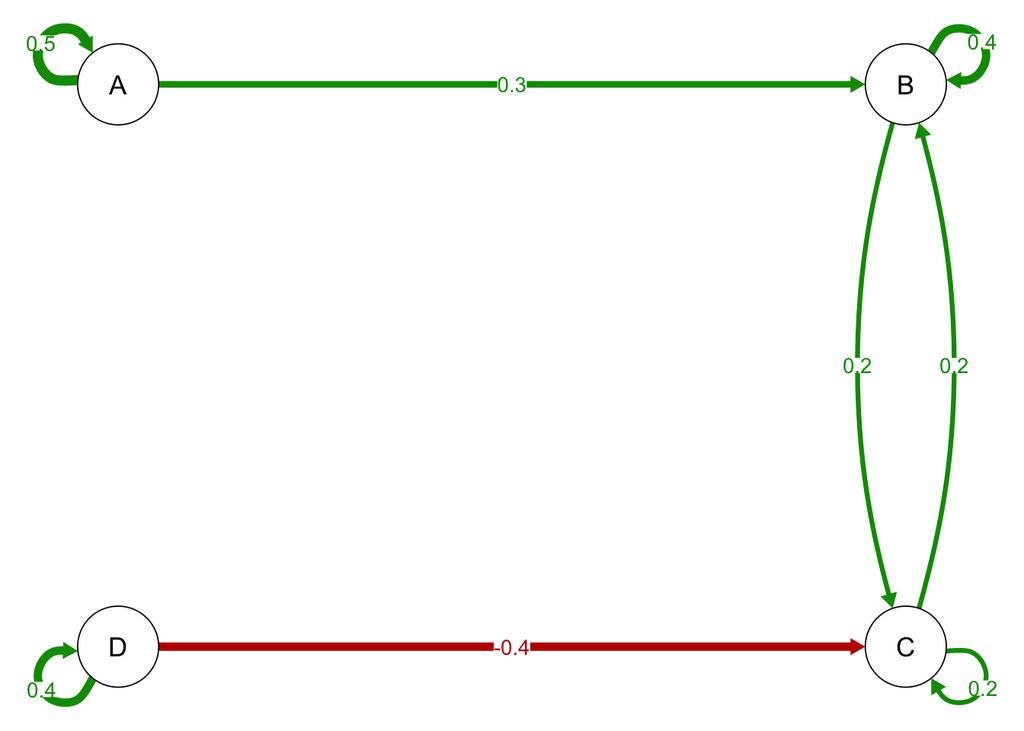

```r
# network visualization
layout <- rbind(c(0,1),
                c(1,1),
                c(1,0),
                c(0,0))
qgraph(t(B), edge.labels = TRUE, layout = layout, fade = FALSE, labels=LETTERS[1:p])
```

# 4 Derive ECM

We can acquire equilibrium model by re-scaling $B$ matrix (marginalizing out diagonal) (Hyttinen, 2012).

```r
# Re-scaling function for the beta matrix
rs_beta <- function(B){
  p <- ncol(B)
  ind <- which(diag(B)!=0)
  if(length(ind)== 0){ return(B)} else {
    U <- matrix(0,p,p)
    # Hytinnen - apply the following repeatedly for all B[i,i] != 0
    for(i in ind){
      # let U be a square 0 matrix with U[i,i] = 1 iff B[i,i] != 0
      U[i,i] <- (B[i,i]/(1-B[i,i]))
    }
    B_t <- B - U%*%(diag(p)-B)
    return(B_t)
  }
}

# Acquire equilibrium model by re-scaling: marginalizaing out diagonal (AR)
B_eq <- rs_beta(B)
dimnames(B_eq) <- list(LETTERS[1:p], LETTERS[1:p])

# check of stability still holds
all(abs(Re(eigen(B_eq)$values)) <= 1)
```

```
[1] TRUE
```

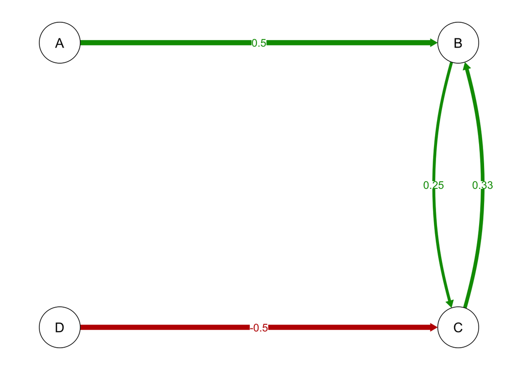

```r
# "static/cross-sectional" cyclic causal graph
qgraph(t(B_eq), edge.labels = TRUE, layout = layout, fade = FALSE, labels=LETTERS[1:p])
```

# 5 Extend model (multiple-subject)

```r
# Re-scaling function for the variance covariance matrix of the intercepts
rs_sigma <- function(S, B){
  p <- ncol(S)
  ind <- which(diag(B)!=0)
  if(length(ind)== 0){ return(S)} else {
    S_t <- S
    # Hytinnen - apply the following repeatedly for all B[i,i] != 0
    for(i in ind){
      # let U be a square 0 matrix with U[i,i] = 1 iff B[i,i] != 0
      U <- matrix(0,p,p) ; I <- diag(p)
      U[i,i] <- 1
      S_t <- (I + (B[i,i]/(1-B[i,i]))*U)%*%S_t%*%t(I + (B[i,i]/(1-B[i,i]))*U)
    }
    return(S_t)
  }
}

# define variance covariance matrix of the intercepts
varint <- 1
Sigma <- diag(varint,p)

# Re-scale covariance matrix for the equilibrium setting
# necessary to generate data correctly under this model
Sigma_eq <- rs_sigma(Sigma, B)
Sigma_eq
```

```
     [,1]     [,2]   [,3]     [,4]
[1,]    4 0.000000 0.0000 0.000000
[2,]    0 2.777778 0.0000 0.000000
[3,]    0 0.000000 1.5625 0.000000
[4,]    0 0.000000 0.0000 2.777778
```

# 6 Simulate data

We simulate data from the equilibrium model. The steps are as follows:  
1. Fix the random seed.  
2. Generate the random intercepts for each person.  
3. Generate the equilibrium positions by *pushing them through* the matrix with the directed parameters.

```r
# step 1
myseed = 123
nsim = 100 # number of simulations
n <- 50000 # sample size
I <- diag(p) # identity matrix
library(future)
plan(multisession)

sim <- future_map(1:nsim, function(x){
  # step 2
  e_eq <- mvrnorm(n, mu = rep(0,p), Sigma = Sigma_eq)
  # step 3
  mu_data_eq <- as.data.frame(t(sapply(1:n,function(i) solve(I - B_eq)%*%e_eq[i,])))
  # specify column names
  colnames(mu_data_eq)<- LETTERS[1:p]

  return(SimData = mu_data_eq)
}, .options = furrr_options(seed = myseed)
)
```

# 7 Fit the model (Recover parameters)

```r
# specify model
mod ="
B  ~ A + C
C ~ B + D
"
# fit sem model
fits <- lapply(sim, function(x) sem(mod, data=x, std.ov=FALSE))

# estimates@Model
beta_est <- lapply(fits, function(x) (lavInspect(x, what = "est")$beta[LETTERS[1:p],LETTERS[1:p]]))

# compare with original Beta
beta_est[1:3] ; B_eq
```

```
[[1]]
          A         B         C          D
A 0.0000000 0.0000000 0.0000000  0.0000000
B 0.4967312 0.0000000 0.3382194  0.0000000
C 0.0000000 0.2504226 0.0000000 -0.4987618
D 0.0000000 0.0000000 0.0000000  0.0000000

[[2]]
          A         B         C          D
A 0.0000000 0.0000000 0.0000000  0.0000000
B 0.4981277 0.0000000 0.3412836  0.0000000
C 0.0000000 0.2454268 0.0000000 -0.5025188
D 0.0000000 0.0000000 0.0000000  0.0000000

[[3]]
          A         B         C          D
A 0.0000000 0.0000000 0.0000000  0.0000000
B 0.4987389 0.0000000 0.3364682  0.0000000
C 0.0000000 0.2504919 0.0000000 -0.4986552
D 0.0000000 0.0000000 0.0000000  0.0000000
```

```
    A    B         C    D
A 0.0 0.00 0.0000000  0.0
B 0.5 0.00 0.3333333  0.0
C 0.0 0.25 0.0000000 -0.5
D 0.0 0.00 0.0000000  0.0
```